### Unit 2: Climate

### Exercise 1.1

Create the same time series figure with 95% confidence intervals for the Greenland ice sheet mass loss.

```r
# Read in data
ant_ice_loss = read.table("data/antarctica_mass_200204_202008.txt", skip=31, sep="", header = FALSE, col.names = c("decimal_date", "mass_Gt", "sigma_Gt")) # Antarctica ice mass loss
grn_ice_loss = read.table("data/greenland_mass_200204_202008.txt", skip=31, sep="", header = FALSE, col.names = c("decimal_date", "mass_Gt", "sigma_Gt")) # Greenland ice mass loss

#Create data.frame with an NA between the GRACE missions. Column names must match so it will merge with ant and grn data
data_break = data.frame(decimal_date=2018.0, mass_Gt=NA, sigma_Gt=NA)
#Add NA data point to the Greenland ice trends data frame
grn_ice_loss_with_NA = rbind(grn_ice_loss, data_break) # Merge grn_ice_loss data frame with our NA point
grn_ice_loss_with_NA = grn_ice_loss_with_NA[order(grn_ice_loss_with_NA$decimal_date),]
```

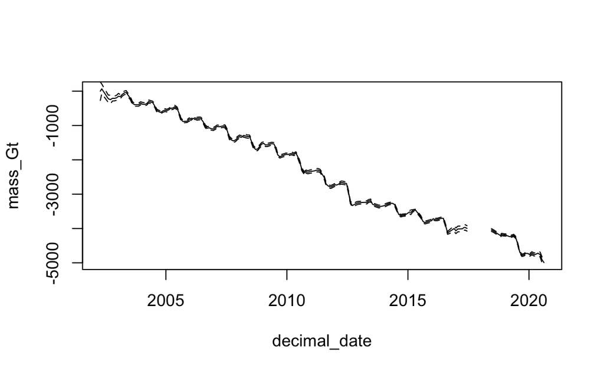

```
## integer(0)
```

```r
head(grn_ice_loss_with_NA)
##   decimal_date mass_Gt sigma_Gt
## 1      2002.29    0.00   134.28
## 2      2002.35   68.26    70.59
## 3      2002.62 -220.33    53.36
## 4      2002.71 -245.50    64.95
## 5      2002.79 -208.84    39.05
## 6      2002.87 -210.53    35.79
plot(mass_Gt ~ decimal_date, data=grn_ice_loss_with_NA, type='l') +
lines((mass_Gt+2*sigma_Gt) ~ decimal_date, data=grn_ice_loss_with_NA, type='l', lty='dashed') +
lines((mass_Gt-2*sigma_Gt) ~ decimal_date, data=grn_ice_loss_with_NA, type='l', lty='dashed')
```

### Exercise 1.2

Calculate the average annual ice loss for each ice sheet by dividing the change in ice lost from the beginning to the end of the time series by the total time that passed. Then display the ice loss rates in a bar graph. Save the bar graph into the `figures/` directory in this repo.

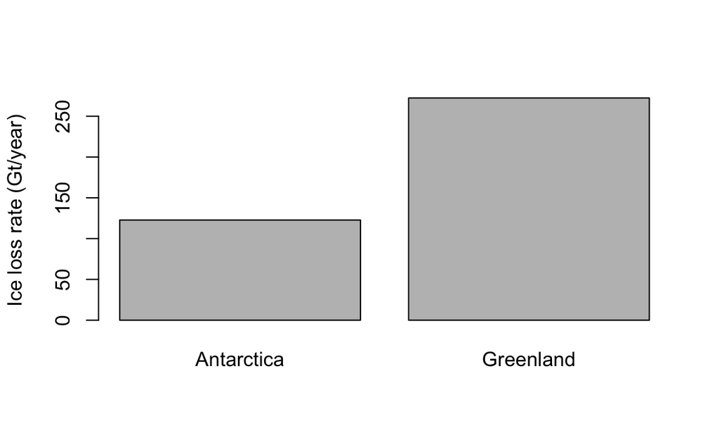

```r
# Calculate ice loss rate (Gt / year) for Antarctica:
n_rows_ant = dim(ant_ice_loss)[1]  # Can use  this to find the last row in the dataset
delta_ice_ant = ant_ice_loss$mass_Gt[n_rows_ant] - ant_ice_loss$mass_Gt[1]
delta_date_ant = ant_ice_loss$decimal_date[n_rows_ant] - ant_ice_loss$decimal_date[1]
ant_loss_rate_Gt_per_yr = -1 * delta_ice_ant / delta_date_ant

# Another option:
# ant_loss_rate_Gt_per_yr = (max(ant_ice_loss$mass_Gt)-min(ant_ice_loss$mass_Gt)) / (max(ant_ice_loss$decimal_date)-min(ant_ice_loss$decimal_date))

# Calculate ice loss rate (Gt / year) for Greenland:
n_rows_grn = dim(grn_ice_loss)[1]
delta_ice_grn = grn_ice_loss$mass_Gt[n_rows_grn] - grn_ice_loss$mass_Gt[1]
delta_date_grn = grn_ice_loss$decimal_date[n_rows_grn] - grn_ice_loss$decimal_date[1]
grn_loss_rate_Gt_per_yr = -1 * delta_ice_grn / delta_date_grn

# Plot ice loss rates in a bar graph:
barplot(height=c(ant_loss_rate_Gt_per_yr, grn_loss_rate_Gt_per_yr), names.arg=c("Antarctica","Greenland"), ylab="Ice loss rate (Gt/year)")
```

To save our bar plot:

```r
pdf('figures/ice_loss_rate.pdf', width=5, height=5)
barplot(height=c(ant_loss_rate_Gt_per_yr, grn_loss_rate_Gt_per_yr), names.arg=c("Antarctica","Greenland"), ylab="Ice loss rate (Gt/year)")
dev.off()
## quartz_off_screen
##                 2
```

### Exercise 2.1

Create a vector with the names of the oceans you have personally visited. Use the `%in%` operator to subset the oceans you have visited from the world_oceans data frame. Now use subsetting to find out whether you have ever personally visited any oceans that have a smaller area than the Atlantic ocean

```r
world_oceans = data.frame(ocean = c("Atlantic", "Pacific", "Indian", "Arctic", "Southern"),
                           area_km2 = c(77e6, 156e6, 69e6, 14e6, 20e6),
                           avg_depth_m = c(3926, 4028, 3963, 3953, 4500))

# Subset the oceans I have visited
my_ocean_names = c("Atlantic", "Pacific")
my_oceans = world_oceans[world_oceans$ocean %in% my_ocean_names, ]

# Which of "my" oceans are smaller than the Atlantic?
Atlantic_area = world_oceans$area[world_oceans$ocean=="Atlantic"]
my_oceans[my_oceans$area < Atlantic_area, ]
## [1] ocean       area_km2    avg_depth_m
## <0 rows> (or 0-length row.names)
```

#### Exercise 2.2

Here are a few random variables. Try converting these sentences into tests written with R code.

```r
w = 15
x = c(-1, 0, 1)
y = "February"
z = c("Monday", "Tuesday", "January")
```

- Is w greater than 10 and less than 20?
- Are any of the values in x positive?
- Are all of the values in x positive?
- Is object y the word February?
- How many values in z are days of the week?

```r
10 < w & w < 20
## [1] TRUE
any(x > 0)
## [1] TRUE
all(x > 0)
## [1] FALSE
y == "February"
## [1] TRUE
sum(z %in% c("Monday", "Tuesday", "Wednesday", "Thursday", "Friday",
  "Saturday", "Sunday"))
## [1] 2
```

#### Exercise 3.1

Let’s say you took someone’s temperature and you want to first evaluate whether or not they have a fever. If they DO have a fever, claculate how different their temperature is from the median human temperature of 98.6 and print out the answer. Also, if they DO have a fever, evaluate whether the fever is high > 101 and if it is, print out a warning message. This will require a set of nested `if()` statements. Test your code with a temperature that is not a fever (`temp = 98.4`), that is a low fever (`temp = 99.5`) and that is a high fever (`temp = 102.1`).

```r
temp = 103

temp_norm = 98.6
temp_high = 101
if (temp > temp_norm){
  diff = temp - temp_norm
  print(paste("Your temp is ", round(diff, digits = 1), "*F above normal"))
  if (temp > temp_high){
    print("Go to the doctor!")
  }
}
## [1] "Your temp is  4.4 *F above normal"
## [1] "Go to the doctor!"
```

### Exercise 3.2

Let’s say you have the number of donuts your Dad bought on Sunday stored in variable `n_donuts`. Write an if/else chain to print out a statement that states whether Dad bought less than a dozen, a dozen (12), a baker’s dozen (13) or more than a baker’s dozen.

```r
n_donuts = 5

if (n_donuts < 12){
  print("I need more donuts!!")
}else if (n_donuts == 12){
  print("Yum! A dozen donuts!")
}else if (n_donuts == 13){
  print("Excellent, a baker's dozen :)")
}else {
  print("Whoa, you bought more than a baker's dozen")
}
## [1] "I need more donuts!!"
```

### Exercise 3.3

Perhaps in a dataset that you are using, the number `-999` is used to indicate a missing value (this is super common). To take advantage of R’s intuitive handling of missing values (in math equations, plotting, etc.) you should replace those elements with `NA`. Use the ifelse() statement to replace all of the `-999` values in the `data` vector with `NA`. Then use an if/else chain to print out a statement about whether there are any `NA`s in the `data` variable. It may help to use functions we covered earlier like `any()` and `is.na()`.

```r
data = c(1,3,5,-999,2,-999,8)

data_with_nas = ifelse(data == -999, NA, data)
data_with_nas
## [1]  1  3  5 NA  2 NA  8

if (any(is.na(data_with_nas))){
  print("There are NAs in this data!")
}else{
  "There are no NAs in this data"
}
## [1] "There are NAs in this data!"
```

### Exercise 4.1

As a result of climate change, there have been many phenological changes in the physical and biological environment. That means that there is a shift in the timing of seasonal phenomena and activities. One of the most obvious examples of this is that as many parts of the world warm, the spring growing season for plants is starting a bit earlier each spring. Plot the seasonal cycle of co2 for 1959 (the first full year of data) and 2019 (the last full year of data) on the same figure. What do you notice? Is this a robust analysis to determine if there has been a phenological shift in global carbon uptake / respiration?

```r
co2_monthly_cycle_1959 = co2[co2$year==1959, c(1,2,9)]
co2_monthly_cycle_2019 = co2[co2$year==2019, c(1,2,9)]

plot(seasonal_cycle ~ month, type="l", data=co2_monthly_cycle_1959, ylim=c(-4,4)) +
lines(seasonal_cycle ~ month, type="l", data=co2_monthly_cycle_2019, col="red")
```

[output not shown]

### Exercise 5.1

Use a for() loop to calculate the factorial (symbol !) of any integer number greater than 0. (For example: 3! = 3*2*1 = 6) Test it with `num = 3` and `num = 6`.

```r
num = 6

factorial = 1
for (i in seq(num)){
  factorial = i*factorial
}
factorial
## [1] 720
```

### Exercise 5.2

Use a while loop to build a simple number matching game. Pick a number between 1 and 10 outside of the loop. Then, inside the loop, step through 1 to 10 and test if that iteration of the loop has guessed the correct number. At the end, print out the number of guesses it took for your loop to guess the right number.

```r
pick = 4
guess = 1
answer = FALSE
while(answer == FALSE){
  if (pick == guess){
    answer = TRUE
  } else{
    guess = guess+1
  }
}

print(paste("My loop guessed your number after ",guess," guesses!"))
## [1] "My loop guessed your number after  4  guesses!"
```

### Exercise 6.1

Use a for loop to calculate the total ice loss in each full decade of the data, starting with 1980-1989. Plot the ice loss per decade in a bar plot.

```r
# Subset only the years I need
ice_decades = arctic_ice_annual[which(arctic_ice_annual$Year >= 1980 & arctic_ice_annual$Year < 2020),]
summary(ice_decades)

# Initialize my results data frame
n_decades = dim(ice_decades)[1]/10
decadal_loss = data.frame(decade = seq(n_decades),
                          decade_name = c("1980s", "1990s", "2000s", "2010s"),
                          ice_loss_million_km2=NA)
# Step through each decade and calculate difference in ice extent btwn the first and last year
for (i in seq(n_decades)){
  # fancy index math:
  print(paste("index from ", (i-1)*10+1, " to ",(i-1)*10+10))
  # calculate decadal ice loss
  decadal_loss$ice_loss_million_km2[i] = ice_decades$extent_annual_avg[(i-1)*10+1] - ice_decades$extent_annual_avg[(i-1)*10+10]
}

barplot(height=decadal_loss$ice_loss_million_km2, names.arg=decadal_loss$decade_name, ylab="Arctic ice loss (million Km^2)")
```

[output not shown]

### Exercise 7.1

Create a function that reads in someone’s grade percentage points and returns their letter grade (A: 90-100, B: 80-90, etc.). You can imagine how you could make this function fancier by including grading scheme info in the parameters to ask if the function user wanted to also know if the student earned a B+, B or B-.

```r
convert_grade_to_letter = function(grade_percent){
  if(grade_percent >= 90){
    grade_letter = "A"
  }else if(grade_percent >= 80){
    grade_letter = "B"
  }else if(grade_percent >= 70){
    grade_letter = "C"
  }else if(grade_percent >= 60){
    grade_letter = "D"
  }else{
    grade_letter = "F"
  }

  grade_letter
}

convert_grade_to_letter(91)
## [1] "A"
convert_grade_to_letter(58)
## [1] "F"
```

### Exercise 8.1

Create a user-defined function that is designed to take this temperature anomaly data frame `temp_anomaly` as a parameter called `data` along with a variable `num_years` that indicates the number of years in the rolling average that someone may want to compute. Have the function return the `temp_anomaly` data frame with an added column called `temp_anomaly$roll_avg` that contains the rolling average corresponding to `num_years`.

### Any length rolling average with the given year as the ENDPOINT:

```r
calc_rolling_avg = function(data, num_years=5){ # Set 5-yr avgs as default
  data$roll_avg = NA # Initialize results column
  # Use for loop to calculate rolling average
  for (i in seq(dim(data)[1]))
  {
    if (i >= num_years & i <= (dim(data)[1])){
      data$roll_avg[i] = mean(data[c((i-(num_years-1)):i),'No_Smoothing'])
    }
  }

  return(data$roll_avg)
}

# Use the calc_rolling_avg() function to calculate rolling averages
temp_anomaly_roll_avg = temp_anomaly
temp_anomaly_roll_avg$avg_5yr = calc_rolling_avg(temp_anomaly)
temp_anomaly_roll_avg$avg_10yr = calc_rolling_avg(temp_anomaly, num_years=10)
temp_anomaly_roll_avg$avg_20yr = calc_rolling_avg(temp_anomaly, num_years=20)
head(temp_anomaly_roll_avg)

# Plot them
plot(No_Smoothing ~ Year, data=temp_anomaly_roll_avg, ylab="Global mean temperature anomaly") +
  lines(No_Smoothing ~ Year, data=roll_avg) +
  lines(avg_5yr ~ Year, data=temp_anomaly_roll_avg, col="red") +
  lines(avg_10yr ~ Year, data=temp_anomaly_roll_avg, col="purple") +
  lines(avg_20yr ~ Year, data=temp_anomaly_roll_avg, col="blue")

# plot it
```

[output not shown]

### Any length rolling average with the given year as the MIDPOINT:

With the midpoint-version of the rolling average calculations, you will need to handle indexing differently if `num_years` is even vs. odd. So make sure you include an if statement in your function with an even vs. odd test. I usually use the modulus operator `%%` in R which returns the remainder of a division operation, so num `%%` 2 equals 0 for even numbers and returns 1 for odd numbers.

```r
# Set 5-yr avgs as default
# If midpoint=TRUE, 5 year average of 2005 is calculated from 2003-2007
# If midpoint=FALSE, 5 year average of 2005 is calculated from 2001-2005
calc_rolling_avg = function(data, num_years=5, midpoint=TRUE){
  data$roll_avg = NA # Initialize results column

  if(midpoint == TRUE){
    # Use for loop to calculate rolling average
    for (i in seq(dim(data)[1]))
    {
      if(num_years %% 2 == 0){ # if even
        lower_index = num_years/2
        upper_index = num_years/2 - 1
        # Calculate moving averages for odd num_years
        if (i > lower_index & i < (dim(data)[1]-upper_index)){
          data$roll_avg[i] = mean(data[c((i-lower_index):(i+upper_index)),'No_Smoothing'])
        }
      } else{ # if odd
        lower_index = (num_years - 1)/2
        upper_index = (num_years - 1)/2
        # Calculate moving averages for even num_years
        if (i > lower_index & i < (dim(temp_anomaly)[1]-upper_index)){
          data$roll_avg[i] = mean(data[c((i-lower_index):(i+upper_index)),'No_Smoothing'])
        }
      }
    }
  } else if (midpoint==FALSE) { # midpoint=FALSE so do an endpoint moving avg
    for (i in seq(dim(data)[1]))
    {
      if (i >= num_years & i <= (dim(data)[1])){
        data$roll_avg[i] = mean(data[c((i-(num_years-1)):i),'No_Smoothing'])
      }
    }

  } else {
    print("midpoint param should be TRUE or FALSE") # could break out of function here
  }

  return(data$roll_avg)
}

# Use the calc_rolling_avg() function to calculate rolling averages
temp_anomaly_roll_avg = temp_anomaly
temp_anomaly_roll_avg$avg_5yr = calc_rolling_avg(temp_anomaly, midpoint=TRUE)
temp_anomaly_roll_avg$avg_10yr = calc_rolling_avg(temp_anomaly, num_years=10, midpoint=TRUE)
temp_anomaly_roll_avg$avg_20yr = calc_rolling_avg(temp_anomaly, num_years=20, midpoint=TRUE)
head(temp_anomaly_roll_avg)

# Plot them
plot(No_Smoothing ~ Year, data=temp_anomaly_roll_avg, ylab="Global mean temperature anomaly") +
  lines(No_Smoothing ~ Year, data=roll_avg) +
  lines(avg_5yr ~ Year, data=temp_anomaly_roll_avg, col="red") +
  lines(avg_10yr ~ Year, data=temp_anomaly_roll_avg, col="purple") +
  lines(avg_20yr ~ Year, data=temp_anomaly_roll_avg, col="blue")

# plot it
```

[output not shown]